# Transport poverty: what it is, why it matters, and how to measure it

Several peripheral parishes were seen as better served than their modelled score.

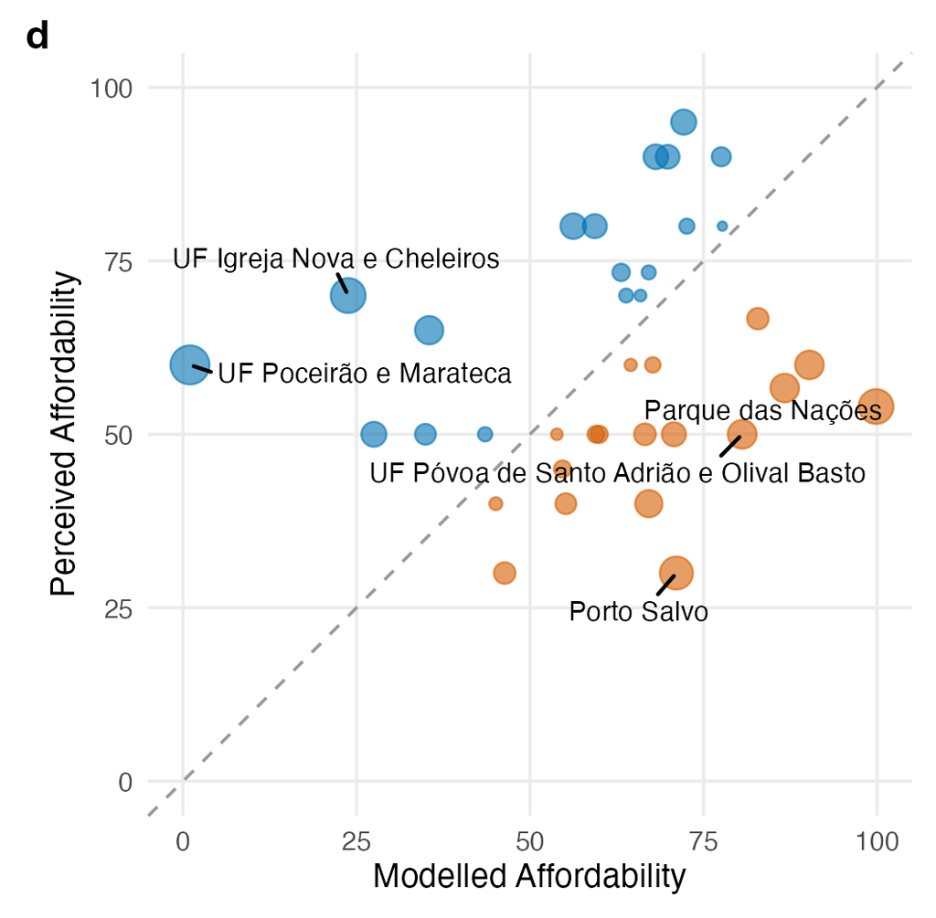

The weakest agreement of the first four (about 0.30).

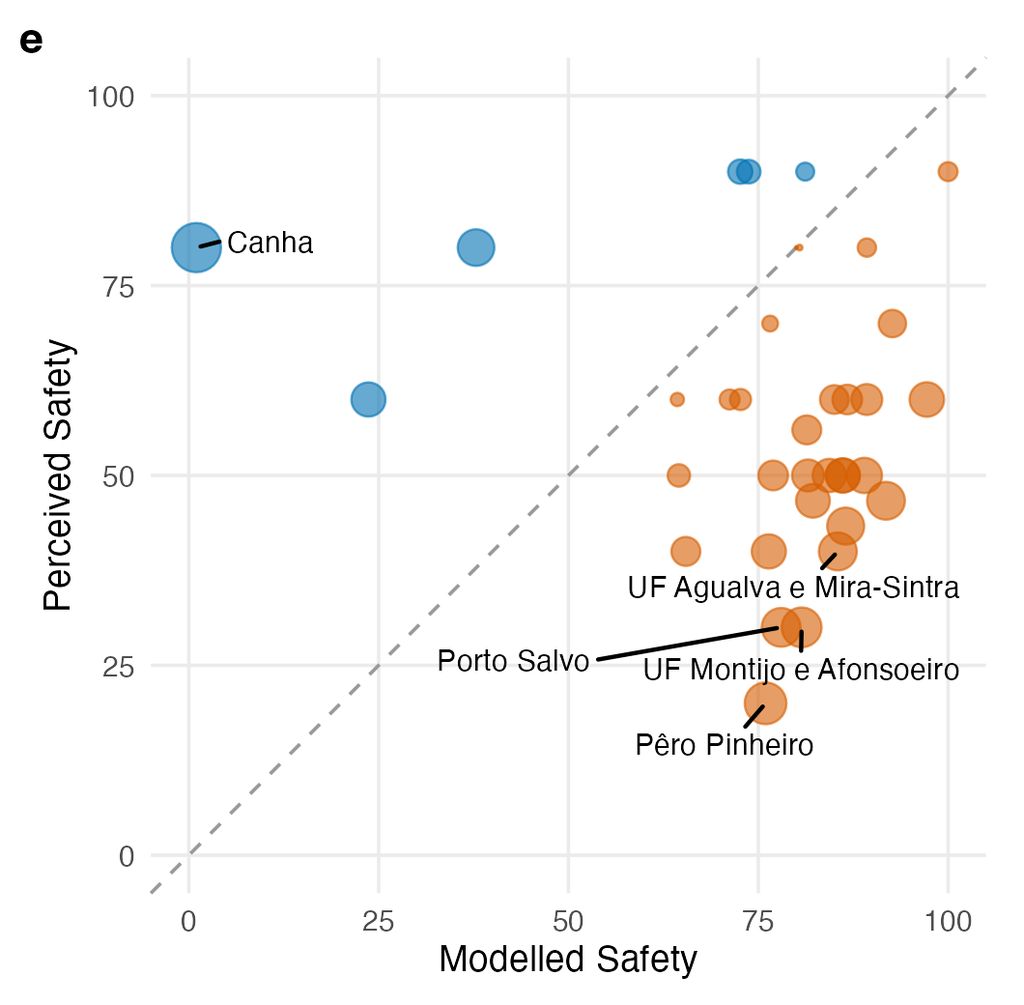

Essentially no rank agreement, and the largest gap.

The disagreement ran both ways: road danger judged higher than the crash record in Pêro Pinheiro or Porto Salvo, and judged good in Canha despite its crash record.

After recomputing on a better population surface, the average gap fell from about 17 to about 5 points.

Blue: participants more optimistic than the model. Orange: more pessimistic. Dashed line: perfect agreement. Dot size: size of the gap. Convenience sample, so read the patterns as hypotheses.

## Back to your words

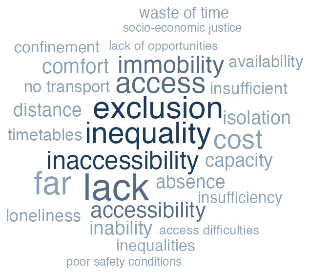

23 workshop participants in Lisbon (translated from Portuguese)

Most frequent: **inequality, exclusion, inaccessibility**; then access, lack and immobility.

[interactive chart not shown]

Your words, from the start of the session. The terms can be read as indirectly reflecting the dimensions of the index.

## Limits and open questions

- **Relative index.** Not designed for comparison over time or across regions without a common benchmark
- **Affordability** has few indicators and needs household-level income and cost data
- **Externalities** are limited to road safety; air quality and noise are still missing
- **Perception and digital access** can be added as further dimensions
- **Decisions stay political**: the index informs where to look, not what to do

> Your turn: which of these would you tackle first, and with what data?

# Take-home messages

## Five things to remember

1. Transport poverty is **inability to reach essential opportunities** because transport is missing, inadequate, unaffordable, slow or unsafe
2. It is **multidimensional**: accessibility, mobility, affordability and externalities can point in different directions
3. Cost-only rules **miss people** who stop travelling and **flag** people who can afford it
4. **Data decide** what can be measured; open, regular data make monitoring possible
5. **Every aggregation choice is a value judgement**: show the composite *and* its parts

## Thank you

**Questions?** Ask in the chat or raise your hand.

**Mauricio Orozco-Fontalvo**  
Dashboard and data: ushift.tecnico.ulisboa.pt/apps/impt  
Methodological report: u-shift.github.io/IMPT-data  
Paper in preparation

[figure not shown]

Research funded by PLANAPP (Science4Policy, PLANAPP-S4P/8042/2025) and FCT under UID/6438/2025 (CERIS).

## References

Aberle, Christoph, Stephan Daubitz, Oliver Schwedes, and Carsten Gertz. 2025. “Measuring Transport Poverty with a Mixed-Methods Approach. A Comparative Case Study of the German Cities Berlin and Hamburg.” *Journal of Transport Geography* 125. https://doi.org/10.1016/j.jtrangeo.2025.104140.

Allen, Jeff, and Steven Farber. 2019. “Sizing up Transport Poverty: A National Scale Accounting of Low-Income Households Suffering from Inaccessibility in Canada, and What to Do about It.” *Transport Policy* 74: 214–23. https://doi.org/10.1016/j.tranpol.2018.11.018.

Alonso-Epelde, E., X. García-Muros, and M. González-Eguino. 2023. “Transport Poverty Indicators: A New Framework Based on the Household Budget Survey.” *Energy Policy* 181: 113692. https://doi.org/10.1016/j.enpol.2023.113692.

Bocarejo S., Juan Pablo, and Daniel Ricardo Oviedo H. 2012. “Transport Accessibility and Social Inequities: A Tool for Identification of Mobility Needs and Evaluation of Transport Investments.” *Journal of Transport Geography* 24 (September): 142–54. https://doi.org/10.1016/j.jtrangeo.2011.12.004.

Dalla Longa, Francesco, Peter Mulder, and Reinier Sterkenburg. 2025. “Stuck in the Sustainable Mobility Transition: A Spatial Analysis of Transport Poverty Risk in the Netherlands.” *Journal of Transport Geography* 127: 104266. https://doi.org/10.1016/j.jtrangeo.2025.104266.

Durand, Anne, Toon Zijlstra, Niels van Oort, Sascha Hoogendoorn-Lanser, and Serge Hoogendoorn. 2022. “Access Denied? Digital Inequality in Transport Services.” *Transport Reviews* 42: 32–57. https://doi.org/10.1080/01441647.2021.1923584.

European Commission. Directorate General for Employment, Social Affairs, and Inclusion. 2024. *Transport Poverty: Definitions, Indicators, Determinants, and Mitigation Strategies: Final Report*. Publications Office of the European Union. https://doi.org/10.2767/0662480.

European Parliament and the Council of the European Union. 2023. “Regulation (EU) 2023/955 of the European Parliament and of the Council of 10 May 2023 establishing a Social Climate Fund and amending Regulation (EU) 2021/1060.” In *Official Journal of the European Union*, 2023/955, vol. L130. https://eur-lex.europa.eu/legal-content/EN/TXT/PDF/?uri=CELEX:32023R0955.

Farber, Steven. 2025. *The Mobilizing Justice National Survey on Transport Poverty: A Tool for Embedding Equity in Transportation Planning*. https://mobilizingjustice.ca/wp-content/uploads/2025/12/FarberS_MJNationalSurvey_version03.pdf.

Fedorowicz, Martha, Emily Bramhall, Mark Treskon, and Richard Ezike. 2020. *New Mobility and Equity: Insights for Medium-Size Cities*. Urban Institute.

Geurs, Karst T., and Bert van Wee. 2004. “Accessibility Evaluation of Land-Use and Transport Strategies: Review and Research Directions.” *Journal of Transport Geography* 12: 127–40. https://doi.org/10.1016/j.jtrangeo.2003.10.005.

Gössling, Stefan. 2016. “Urban Transport Justice.” *Journal of Transport Geography* 54: 1–9. https://doi.org/10.1016/j.jtrangeo.2016.05.002.

Hidayati, Isti, Wendy Tan, and Claudia Yamu. 2021. “Conceptualizing Mobility Inequality: Mobility and Accessibility for the Marginalized.” *Journal of Planning Literature* 36: 492–507. https://doi.org/10.1177/08854122211012898.

Imprialou, Marianna, and Mohammed Quddus. 2019. “Crash Data Quality for Road Safety Research: Current State and Future Directions.” *Accident Analysis & Prevention* 130: 84–90. https://doi.org/10.1016/j.aap.2017.02.022.

Instituto Nacional de Estatística. 2018. *Inquérito à Mobilidade Nas Áreas Metropolitanas Do Porto e de Lisboa — IMOB 2017*. https://www.ine.pt/xurl/pub/349495406.

Isalou, Ali A., Todd Litman, and Behzad Shahmoradi. 2014. “Testing the Housing and Transportation Affordability Index in a Developing World Context: A Sustainability Comparison of Central and Suburban Districts in Qom, Iran.” *Transport Policy* 33: 33–39. https://doi.org/10.1016/j.tranpol.2014.02.006.

Kelly, J. A., L. Kelleher, Y. Guo, C. Deegan, and A. Patil. 2023. “Transport Poverty Risk – a Composite Spatial Index to Support Policy Design and Investment Targeting as Part of a Just Climate Transition.” *Environmental and Sustainability Indicators* 18: 100254. https://doi.org/10.1016/j.indic.2023.100254.

Levinson, David M., and David King. 2020. *Transport Access Manual: A Guide for Measuring Connection Between People and Places*. https://hdl.handle.net/2123/23733.

Litman, Todd. 2026. “Evaluating Transportation Affordability.” In *Victoria Transport Policy Institute*. https://www.vtpi.org/affordability.pdf.

Lopes, André Soares, Mauricio Orozco-Fontalvo, Filipe Moura, and David Vale. 2023. “Mobility as a Service and Socio-Territorial Inequalities: A Systematic Literature Review.” *Journal of Transport and Land Use* 16 (1): 215–40. https://doi.org/10.5198/jtlu.2023.2273.

Lowans, Christopher, Dylan Furszyfer Del Rio, Benjamin K. Sovacool, David Rooney, and Aoife M. Foley. 2021. “What Is the State of the Art in Energy and Transport Poverty Metrics? A Critical and Comprehensive Review.” *Energy Economics* 101: 105360. https://doi.org/10.1016/j.eneco.2021.105360.

Lucas, Karen, Giulio Mattioli, Ersilia Verlinghieri, and Alvaro Guzman. 2016. “Transport Poverty and Its Adverse Social Consequences.” *Proceedings of the Institution of Civil Engineers - Transport* 169 (6): 353–65. https://doi.org/10.1680/jtran.15.00073.

Mattioli, Giulio. 2017. “’Forced Car Ownership’ in the UK and Germany: Socio-Spatial Patterns and Potential Economic Stress Impacts.” *Social Inclusion* 5 (4): 147–60. https://doi.org/10.17645/si.v5i4.1081.

Mattioli, Giulio, Karen Lucas, and Greg Marsden. 2018. “Reprint of Transport Poverty and Fuel Poverty in the UK: From Analogy to Comparison.” *Transport Policy* 65: 114–25. https://doi.org/10.1016/j.tranpol.2018.02.019.

Mejia-Dorantes, L., and I. Murauskaite-Bull. 2022. *Transport Poverty: A Systematic Literature Review in Europe*. Publications Office of the European Union. https://doi.org/10.2760/793538.

OECD, European Union, and Joint Research Centre - European Commission. 2008. *Handbook on Constructing Composite Indicators: Methodology and User Guide*. OECD Publishing. https://doi.org/10.1787/9789264043466-en.

Pereira, Rafael H. M., and Daniel Herszenhut. 2023. *Introdução à Acessibilidade Urbana: Um Guia Prático Em r*. Instituto de Pesquisa Econômica Aplicada. https://doi.org/10.38116/9786556350547.

Pereira, Rafael H. M., Marcus Saraiva, Daniel Herszenhut, Carlos K. V. Braga, and Matthew Wigginton Conway. 2021. “R5r: Rapid Realistic Routing on Multimodal Transport Networks with R5 in R.” *Findings*, ahead of print. https://doi.org/10.32866/001c.21262.

Primc, Kaja, Darja Zabavnik, Renata Slabe-Erker, and Miha Dominko. 2025. “Transport Poverty Vulnerability Index: Making Use of Standardised Databases.” *Energy Research & Social Science* 123: 104041. https://doi.org/10.1016/j.erss.2025.104041.

Pritchard, John P., Filipe Moura, João de Abreu e Silva, and Luiz M. Martinez. 2014. “Spatial Analysis of Transportation-Related Social Exclusion in the Lisbon Metropolitan Area.” *Procedia - Social and Behavioral Sciences* 111: 440–49. https://doi.org/10.1016/j.sbspro.2014.01.077.

Unit, Social Exclusion. 2003. *Making the Connections: Final Report on Transport and Social Exclusion*. Social Exclusion Unit.

Verhorst, Tom, Xingxing Fu, and Dea van Lierop. 2023. “Definitions Matter: Investigating Indicators for Transport Poverty Using Different Measurement Tools.” *European Transport Research Review* 15 (1): 21. https://doi.org/10.1186/s12544-023-00596-z.